# Airborne Laser Scanning - A Global Perspective

Author

Fabian Jörg Fischer

Published

February 24, 2026

## 1 Introduction

Airborne Laser Scanning (ALS), also known as LiDAR (Light Detection and Ranging), is a remote sensing technology that uses pulsed laser light to measure distances to the Earth’s surface. It has become a critical tool for characterizing forest structure and mapping terrain at high resolution.

This document provides an overview of ALS technology, its applications in forest ecology, important considerations when working with ALS data, and resources for further learning. **The perspective presented here draws from analysis of a global collection of airborne laser scanning data** spanning diverse forest types and ecosystems, from tropical rainforests to boreal forests, providing insights into both the capabilities and limitations of ALS across different environments.

## 2 Terminology and Technology

### 2.1 What is ALS?

**Airborne Laser Scanning** (also referred to as **lidar**, **LiDAR**, or **ALS**) is an active remote sensing technology that operates from airborne platforms. **When we refer to “airborne laser scanning” or “airborne LiDAR,” this includes both traditional aircraft/helicopter-based systems and UAV-based LiDAR systems.** The system emits rapid laser pulses toward the ground and measures the time it takes for the light to return to the sensor.

**NoteKey Terms and Terminology**

**Interchangeable terms** (all mean the same thing): - Airborne Laser Scanning (ALS) - Airborne LiDAR - lidar - LiDAR

Don’t be confused by the different spellings and capitalizations!

**Additional important terms:** - **Point Cloud**: Three-dimensional collection of georeferenced points representing surfaces - **Terrestrial LiDAR (TLS)**: Ground-based variant for high-resolution local measurements (Jucker et al. 2023) - **Full Waveform**: Complete energy distribution of returned laser pulse - **Returns**: Individual reflections detected from a laser pulse (first return, last return, etc.)

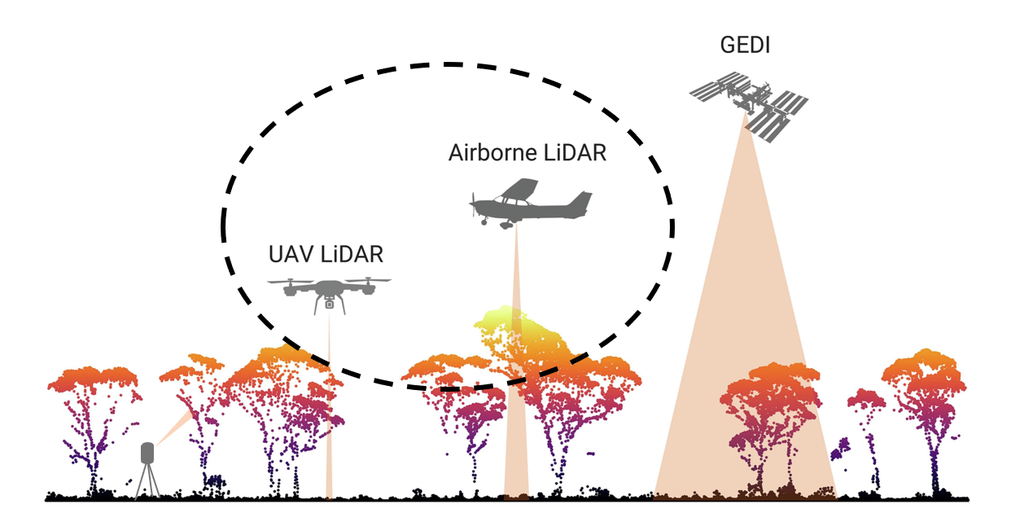

### 2.2 How It Works: Full Waveform vs. Point Clouds

ALS systems technically record complete waveforms, but most applications use discretized data:

1. **Full Waveform LiDAR**: Records the complete energy distribution of the returned laser pulse, providing detailed information about vegetation structure at multiple heights. However, this is very information-rich and computationally demanding.
2. **Discrete Return (Point Clouds)**: Processes the waveform into individual return points using algorithms (usually provided by manufacturers). **Approximately 99% of ALS applications** use this discretized version, which is more compressed, easier to analyze, and simpler to share. Discrete returns typically capture:
   - **First return**: Top of canopy
   - **Intermediate returns**: Mid-canopy vegetation
   - **Last return**: Ground surface

**NoteWaveform to Point Cloud Conversion**

The conversion from full waveform to discrete returns involves identifying peaks in the returned energy signal. This discretization makes the data more manageable while retaining most of the useful structural information for forest analysis.

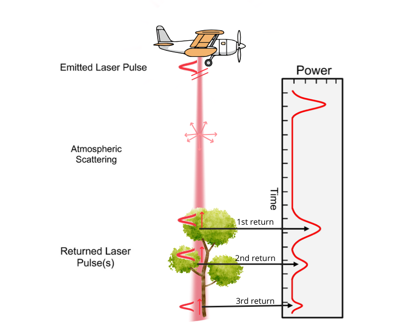

Figure 2: Comparison of full waveform data and discrete point cloud returns. Adapted from Yan, Shaker, and El-Ashmawy (2015)

[figure not shown]

Figure 3: NEON airborne laser scanning data example. Source: NEON (2024)

## 3 Why Airborne Laser Scanning?

ALS provides several key advantages over other remote sensing approaches for forest structure characterization.

### 3.1 Spatial Coverage and Resolution

ALS provides **continuous, high-resolution coverage** over large areas, which cannot be achieved with ground-based measurements and generally offers much higher spatial detail than spaceborne alternatives.

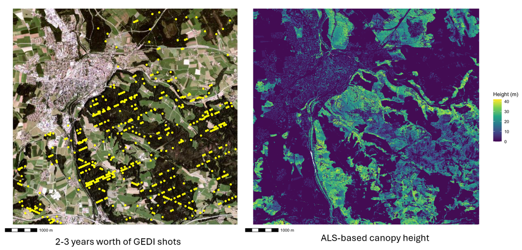

Figure 4: Comparison 2-3 years of GEDI satellite shots (discrete points) versus ALS-based canopy height (continuous coverage).

### 3.2 Key Applications

**General Applications**

[figure not shown]

Figure 5: Key applications of airborne laser scanning in ecology and forestry. Adapted from Lang et al. (2023).

**Global Models**

ALS serves as **reference data** for training and validating global-scale models of forest structure, biomass, and carbon stocks

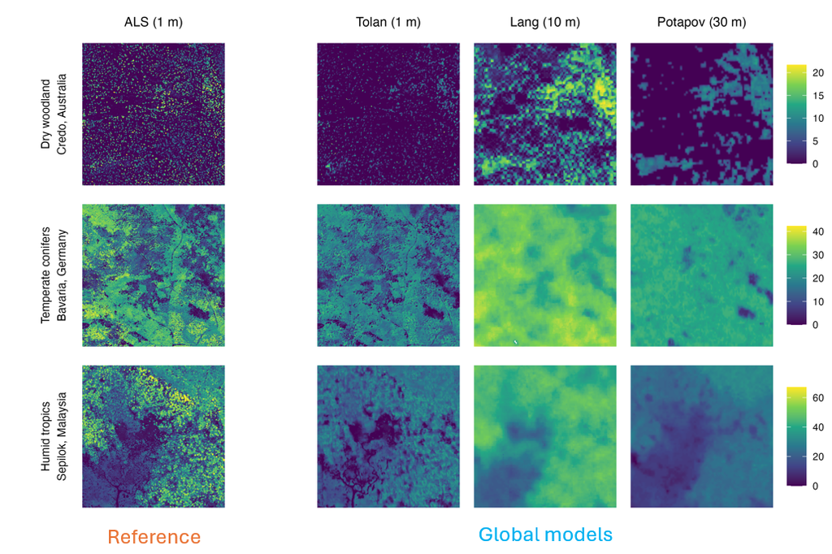

Figure 6: ALS as reference data for global models. Source: Fischer et al. (in preparation).

**Open Data Access**

Large collections of ALS data are increasingly available through open-access platforms (OpenTopography 2024).

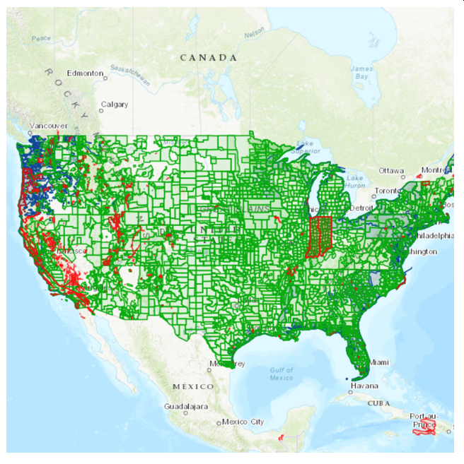

Figure 7: OpenTopography platform for accessing lidar data. Source: OpenTopography (2024).

**Forest Monitoring**

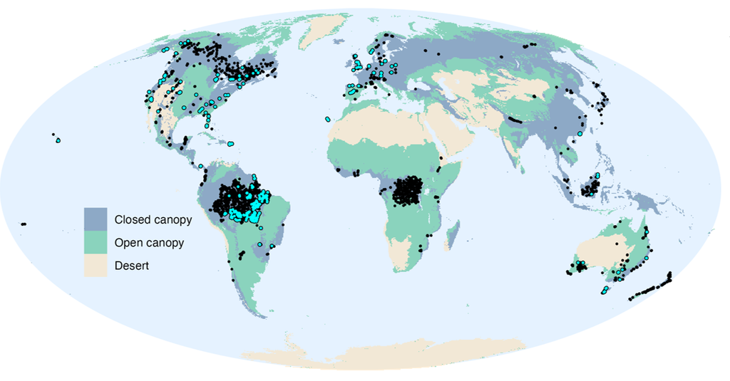

Figure 8: ALS applications in forest monitoring and research. Source: Fischer et al. (in preparation).

**Ecosystem Studies**

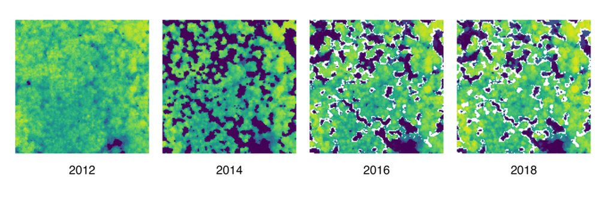

Figure 9: Ecosystem-level applications of ALS technology. Source: Fischer et al. (in preparation).

**WarningA Critical Warning About Global Canopy Height Models**

Recent years have seen the emergence of global-scale canopy height models that combine satellite LiDAR (GEDI) with optical imagery. While these represent important progress, **users should exercise extreme caution when using them for ecological analyses at present.**

While these models capture general trends between biomes, they are **not operationally useful for most ecological studies at present.** For local to landscape-scale research, high-quality ALS data remains essential.

### 3.3 Advantages Over Other Methods

| Method | Coverage | Resolution | Canopy Penetration | Cost |
| --- | --- | --- | --- | --- |
| **ALS** | Regional to landscape | Very high (cm-m) | Excellent | High |
| **Satellite LiDAR (GEDI)** | Global (discrete) | Footprints (~25m) | Good | Low (public) |
| **Optical imagery** | Global | Medium-high | None | Low-Medium |
| **Field measurements** | Local plots | Very high | Complete | High |

## 4 Word of Warning: Important Considerations

While ALS is a powerful tool, several factors affect data quality and interpretation. Understanding these limitations is crucial for proper application.

### 4.1 Ecosystems Vary

**WarningMethod Performance Varies by Forest Type**

Many established ALS processing methods have been **developed and tested primarily in:**

- Open canopy systems
- Conifer-dominated forests
- Temperate deciduous forests

These methods include:

- Ground point detection
- Individual tree segmentation
- Understory characterization

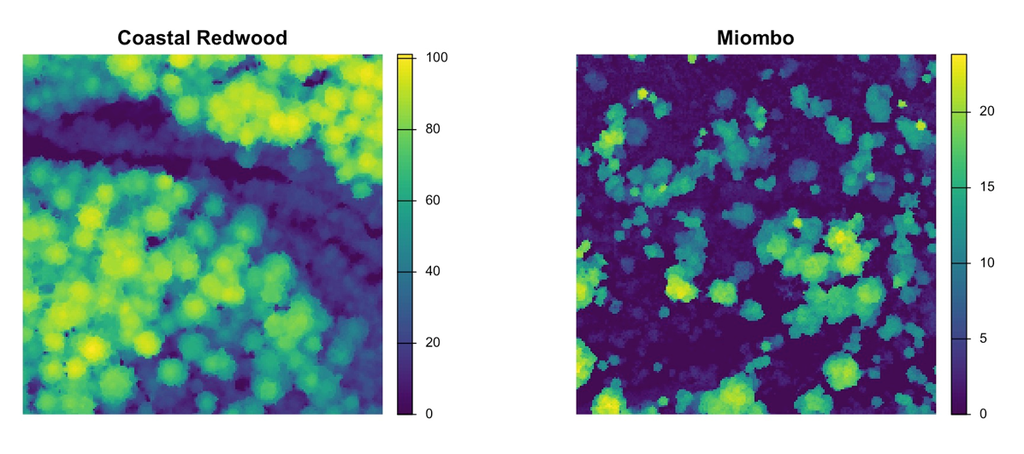

Figure 10: Example of coniferous forest: a lot of methods have been developed and work well in conifer forests or open systems (ground detection, tree segmentation, understory assessments).

**ImportantChallenges in Dense Forests**

**Many methods do not work as well in:**

- Dense, closed-canopy deciduous forests
- Tropical and subtropical forests
- Multi-layered forest structures

In these environments:

- Ground detection becomes unreliable
- Tree segmentation is highly uncertain
- Individual tree metrics may be impossible to extract

**Note on AI and deep learning approaches:** Even advanced AI techniques struggle with individual tree segmentation in closed-canopy forests. A fundamental limitation applies here: **if human experts cannot reliably delineate individual tree crowns, AI methods are unlikely to perform better.** This is not a temporary technical limitation but rather reflects the physical reality of overlapping, intertwined canopies in dense forests.

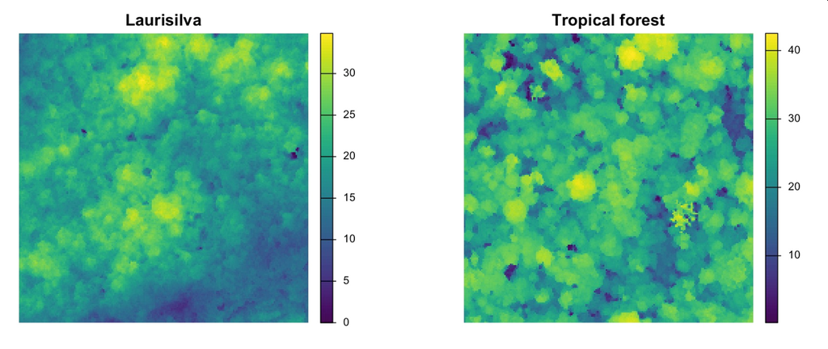

Figure 11: Dense tropical forest: a lot of methods do not work so well in dense, closed-canopy deciduous forests (especially in the tropics and subtropics).

### 4.2 Instruments Vary

ALS data quality and characteristics depend heavily on:

- **Acquisition season**
- **Sensor specifications**
- **Flight parameters**
- **Processing approaches**

#### 4.2.1 Seasonal Effects

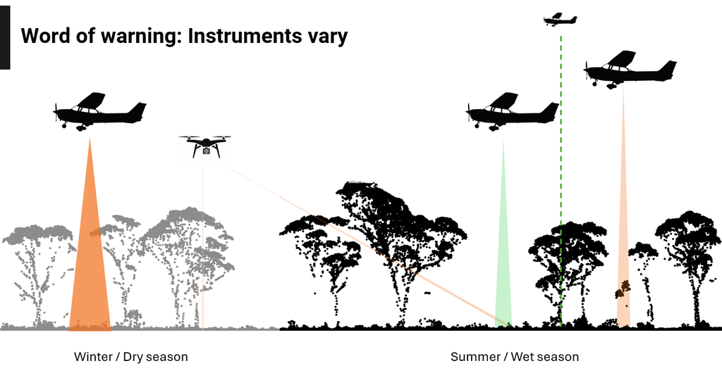

Figure 12: Comparison of winter/dry season (leaf-off) versus summer/wet season (leaf-on) acquisitions. Leaf-off conditions provide better ground penetration, while leaf-on better represents canopy structure

**NoteSeasonal Trade-offs**

**Winter / Dry Season (Leaf-off):**

- ✅ Better ground detection
- ✅ Improved terrain modeling
- ❌ Underestimates canopy metrics
- ❌ Missing deciduous foliage

**Summer / Wet Season (Leaf-on):**

- ✅ Complete canopy structure
- ✅ Accurate height measurements
- ❌ Reduced ground penetration
- ❌ More challenging DTM generation

#### 4.2.2 Sensor Characteristics

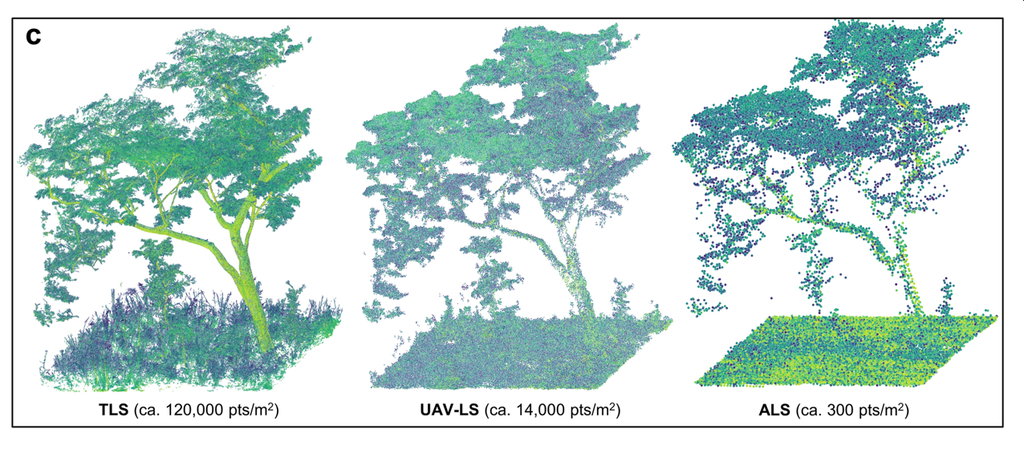

Figure 13: Impact of different sensor characteristics on forest structure retrieval. Adapted from Demol et al. (2024)

**Key sensor parameters affecting data quality:**

- **Pulse density**: Higher is generally better (5-15+ pulses/m² recommended)
- **Wavelength**: Near-infrared (1064 nm) vs. green (532 nm) - different wavelengths interact differently with vegetation and water
- **Beam divergence**: Affects footprint size and penetration. Wide beams are more sensitive to upper canopy elements (hitting something at the top), while narrow beams can penetrate small gaps more easily
- **Scan angle**: Central scan (nadir) vs. oblique angles
- **Flight altitude**: Trade-off between coverage and resolution

**WarningCross-Sensor Comparisons Require Caution**

**Within a single study area scanned with the same system**, you can use relatively complex structural metrics safely. However, **when comparing across different sensors or acquisition campaigns**, you must be much more careful:

- **Simple metrics** (e.g., mean canopy height, percentile heights) are generally comparable across sensors
- **Complex structural metrics** (e.g., entropy, fractal dimension, box dimension) can be problematic when comparing different scans
- **Risk**: You may inadvertently measure differences between sensors rather than differences between environments

**Recommendation:** When working across multiple sensors or platforms, prioritize simple, interpretable metrics over complex ones. If you use structural complexity metrics, ensure you understand exactly how they work and validate that sensor differences don’t drive your results.

**NoteCommercial Software for Ground Classification**

For ground point classification specifically, commercial software (such as LAStools) often still outperforms open-source alternatives. If you receive point clouds that have been pre-classified by a company, **use those classifications rather than re-classifying** with your own tools. Commercial providers often employ manual corrections and have refined their algorithms over many years, making their ground classifications more reliable.

## 5 Robust Interpretation Approaches

To maximize reliability and minimize artifacts, different modeling approaches can be applied depending on research objectives and forest characteristics.

### 5.1 Surface Models (Pixels)

**Raster-based** approach creating 2D gridded products. This is **the most common product from airborne laser scanning** and what ALS analysis historically started with.

**The basic concept:** Imagine draping a cloth over your point cloud. The cloth falls and settles onto the points, creating a continuous surface. You can control how far the cloth drops into gaps by adjusting weights - strong weights let it fall into small gaps, while lighter weights create a smoother surface that bridges over gaps.

The difference between DSM and DTM gives you the Canopy Height Model (CHM).

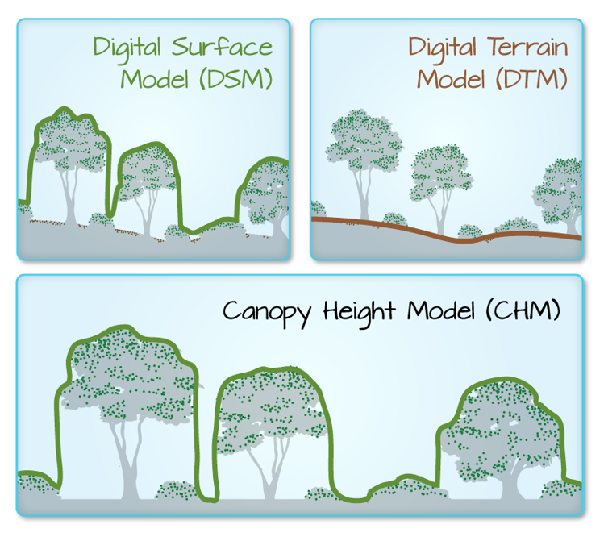

Figure 14: Example of pixel-based surface model approach. Source: NEON (2024).

**Common raster products:**

- **Digital Terrain Model (DTM)**: Ground elevation
- **Digital Surface Model (DSM)**: Top-of-canopy elevation
- **Canopy Height Model (CHM)**: Vegetation height (DSM - DTM)
- **Intensity**: Laser return strength

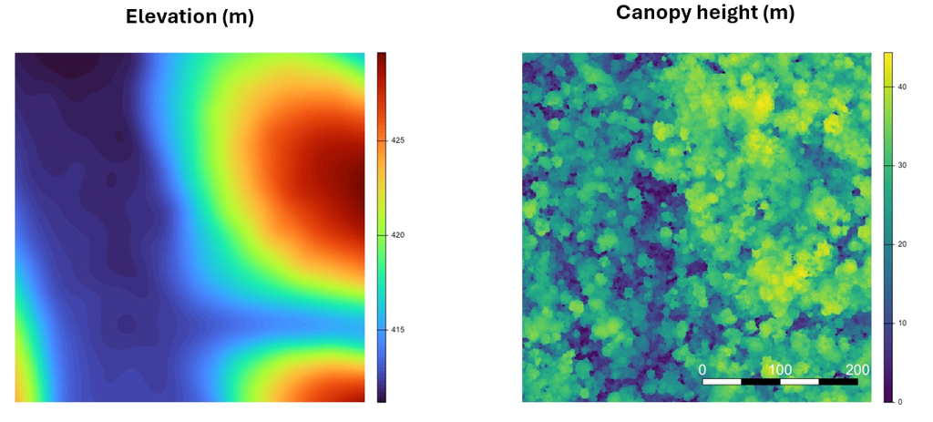

Figure 15: Example of elevation (left) and canopy height (right).

**NoteEcological Patterns Visible in Canopy Structure**

An interesting observation from processing ALS data globally: **you can often recognize terrain patterns directly from canopy height models**, even without looking at the elevation data. This is particularly evident in areas with subtle topography (like the Congo example above, with only 20-25m elevation change).

This demonstrates that canopy height models capture not just structure but also underlying ecological processes and resource distribution patterns.

**TipWhen to Use Surface Models**

**Advantages:**

- Well-established processing workflows
- Computationally efficient
- Easy to integrate with other spatial data
- Suitable for large-area analysis

**Best for:**

- Regional forest inventories
- Biomass estimation
- Terrain mapping
- Change detection over time

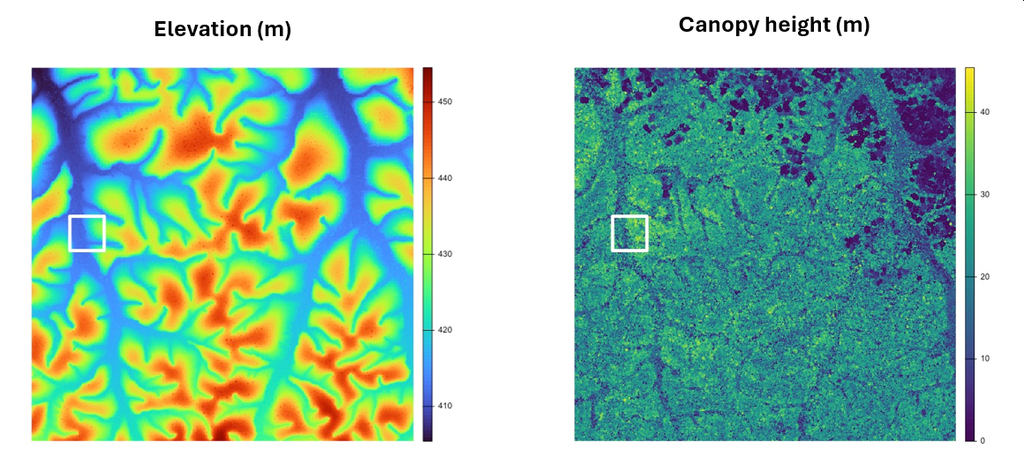

Figure 16: Detailed view of canopy height and elevation.

### 5.2 Volume Models (Voxels)

**Three-dimensional** volumetric approach that preserves vertical structure information. More computationally intensive but provides richer ecological information.

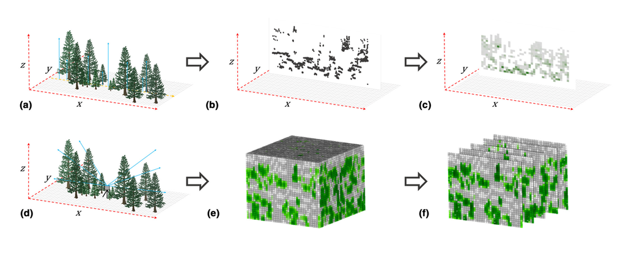

Figure 17: Voxel model example: example of voxel-based volume model approach. Source: Atkins et al. (2018)

**Voxel-based products:**

- **3D occupancy grids**: Presence/absence of vegetation in 3D space
- **Plant Area Density (PAD)**: Vertical distribution of vegetation
- **Structural complexity metrics**: Diversity of vertical arrangements
- **Light penetration models**: Understory light availability

**TipWhen to Use Volume Models**

**Advantages:**

- Preserves full 3D structure
- Better for complex, multi-layered forests
- Captures understory information
- More ecologically meaningful metrics

**Best for:**

- Habitat quality assessment
- Biodiversity studies
- Structural complexity analysis
- Light environment modeling

**Limitations:**

- Computationally demanding
- Requires higher point densities
- More complex processing pipelines
- Larger data storage requirements

### 5.3 Choosing an Approach

| Criterion | Surface Models (Pixels) | Volume Models (Voxels) |
| --- | --- | --- |
| **Processing complexity** | Low | High |
| **Computational demand** | Low | High |
| **Data requirements** | Moderate point density | High point density |
| **Forest type suitability** | All types | Complex, multi-layered |
| **Ecological detail** | Canopy-focused | Full 3D structure |
| **Analysis scale** | Regional to global | Local to landscape |

## 6 Resources for Learning and Analysis

### 6.1 Tutorials and Documentation

**NoteEssential Learning Resources**

**Interactive Introductions:**

- NOAA Digital Coast Training (NOAA 2024): https://coast.noaa.gov/digitalcoast/training/intro-lidar.html
- NEON LiDAR Basics (NEON 2024): https://www.neonscience.org/resources/learning-hub/tutorials/lidar-basics

**Open Source Processing:**

- lidR Package for R (Roussel and Auty 2024): https://r-lidar.github.io/lidRbook/
- Terra Package for R (rasters) (Hijmans 2024): https://rspatial.org/spatial/index.html

**Commercial Software:**

- LAStools (Isenburg 2024): https://rapidlasso.de/product-overview/
- LAStools User Forum: https://groups.google.com/g/lastools

**Methodological Papers:**

- Surface models (pixel-based) (Fischer, Maréchaux, and Chave 2024): https://doi.org/10.1111/2041-210X.14416
- Volume models (voxel-based) (AMAP Laboratory 2024): https://amapvox.org/

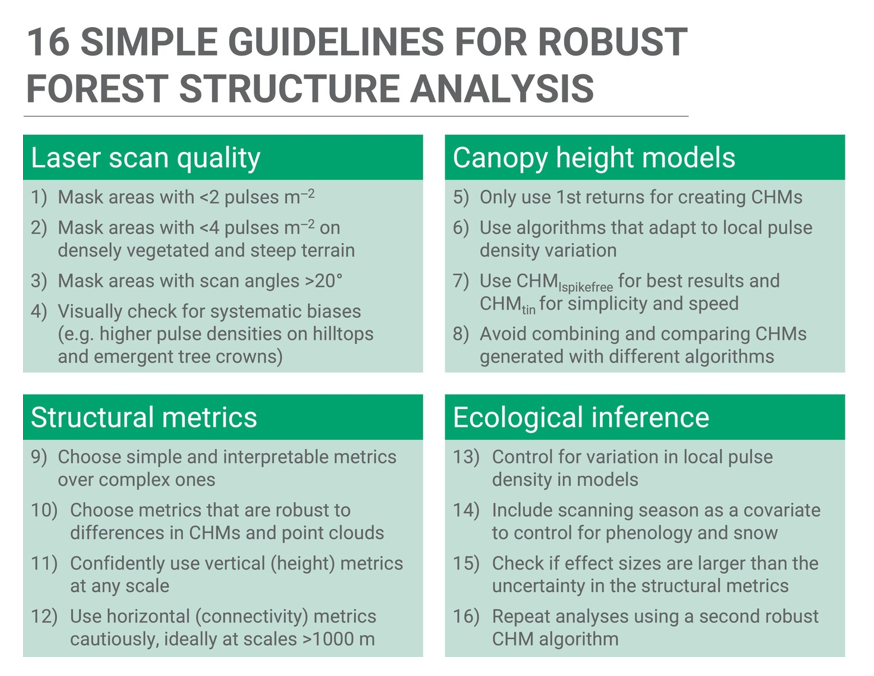

Figure 18: Key methodological paper on surface model approaches. Source: Fischer, Maréchaux, and Chave (2024).

### 6.2 Data Access

**TipWhere to Find ALS Data**

**Open Access Repositories:**

- **OpenTopography** (OpenTopography 2024): https://opentopography.org/ (USA and international)
- **NEON** (NEON 2024): https://www.neonscience.org/ (USA ecological sites)
- **USGS 3DEP**: https://www.usgs.gov/3d-elevation-program (USA nationwide)
- **National Programs**: Many countries have open lidar programs

**Regional Coverage Notes:**

- **United States**: Extensive coverage, with most areas scanned at least once. Many locations have multiple temporal acquisitions available through OpenTopography
- **Europe**: Variable - some countries like **Spain** provide excellent open access with multiple temporal scans, while others like **Germany** have mixed policies (some states provide open access, others do not)
- **Other regions**: Check national mapping agencies and research institutions for available data

**Tips for Data Access:**

- Check if your study area has existing coverage
- Consider acquisition date and season
- Review metadata for pulse density and accuracy
- Download sample data before committing to large datasets
- For multi-temporal studies, check if multiple acquisitions exist for your area

## 7 Practical Applications and Exercises

### 7.1 Getting Started with ALS Analysis

**NoteRecommended Workflow**

**Preparation:**

1. **Form groups** of 2-3 people (at least one familiar with R/RStudio)
2. **Review tutorials** from lidR handbook and NEON
3. **Download sample data** for your region of interest
4. **Familiarize yourself** with basic concepts before analysis

**Analysis Steps:**

1. Start with simple metrics: DTM, CHM, mean height
2. Experiment with parameters: resolution, filtering, algorithms
3. Compare different methods (TIN vs highest point, different resolutions)
4. Validate results: Compare with field data or expectations

**Key Considerations:**

- What is the ecological context? (forest type, structure)
- What is the data quality? (pulse density, season, coverage)
- What are the research questions? (canopy height, biomass, diversity)
- What validation data are available? (field plots, imagery)

### 7.2 Pre-Analysis Questions to Consider

Before processing ALS data, think about:

1. **Forest Structure Expectations:**
   - What is the typical tree height in your study area?
   - Is the canopy open or closed?
   - Are there distinct canopy layers?
2. **Data Quality Assessment:**
   - What is the pulse density?
   - What season was it acquired?
   - Are there coverage gaps?
3. **Method Selection:**
   - Do you need individual trees or area statistics?
   - Is terrain modeling critical?
   - What spatial resolution is appropriate?
4. **Validation Strategy:**
   - Are field measurements available?
   - Can you compare with other data sources?
   - How will you assess uncertainty?

### 7.3 Hands-On Practice

**TipTutorial Workflow**

Follow the companion tutorials (tutorial1.qmd and tutorial2.qmd) to:

- Process raw point cloud data
- Generate DTMs and CHMs
- Calculate forest structure metrics
- Analyze temporal changes
- Evaluate uncertainties and artifacts

Work through these systematically, paying attention to parameter choices and their effects on results.

## 8 Summary and Key Takeaways

**Technology**

**Airborne Laser Scanning (ALS):**

- Active remote sensing using laser pulses
- Creates 3D point clouds of terrain and vegetation
- Penetrates forest canopy to measure ground and structure
- Available as full waveform or discrete returns

**Applications**

**Primary Uses:**

- High-resolution canopy height mapping
- Terrain modeling (DTM/DEM)
- Forest biomass estimation
- Reference data for global models
- Habitat and biodiversity assessment
- Change detection and monitoring

**Considerations**

**Important Limitations:**

- Methods vary in effectiveness by ecosystem type
- Sensor characteristics strongly affect data quality
- Seasonal effects (leaf-on vs. leaf-off)
- Processing approach affects reliability
- Requires careful interpretation and validation

**Best Practices**

**For Reliable Analysis:**

- Understand your forest system characteristics
- Check data quality metrics (pulse density, coverage)
- Consider seasonal effects on your research question
- Choose appropriate modeling approach (pixels vs. voxels)
- Validate results when possible
- Document all processing steps and parameters

## 9 Conclusion

Airborne Laser Scanning has revolutionized our ability to measure forest structure at scales from individual trees to entire regions. However, successful application requires understanding both the technology’s capabilities and its limitations.

**Key recommendations for working with ALS data:**

1. **Know your ecosystem**: Different forest types require different approaches
2. **Understand your data**: Sensor specs and acquisition conditions matter
3. **Choose appropriate methods**: Match analysis approach to research questions
4. **Validate results**: Ground-truth when possible, sanity-check always
5. **Stay current**: Methods and best practices continue to evolve

The resources provided in this document offer pathways for deeper learning, from introductory tutorials to advanced methodological papers. The combination of openly available data and open-source processing tools makes ALS analysis increasingly accessible to the research community.

## 10 References

AMAP Laboratory. 2024. “AMAPVox: Voxel-Based LiDAR Analysis Software.” https://amapvox.org/.

Atkins, Jeff W, Gil Bohrer, Robert T Fahey, Brady S Hardiman, Timothy H Morin, Atticus EL Stovall, Naupaka Zimmerman, and Christopher M Gough. 2018. “Quantifying Vegetation and Canopy Structural Complexity from Terrestrial Li DAR Data Using the Forestr r Package.” *Methods in Ecology and Evolution* 9 (10): 2057–66.

Demol, Miro, Naikoa Aguilar-Amuchastegui, Gabija Bernotaite, Mathias Disney, Laura Duncanson, Elise Elmendorp, Andres Espejo, et al. 2024. “Multi-Scale Lidar Measurements Suggest Miombo Woodlands Contain Substantially More Carbon Than Thought.” *Communications Earth & Environment* 5 (1): 366.

Fischer, Fabian Jörg et al. in preparation. “Global-Scale Canopy Height Modeling Using Airborne Laser Scanning and GEDI Data.”

Hijmans, Robert J. 2024. “Spatial Data Analysis with Terra.” https://rspatial.org/spatial/index.html.

Isenburg, Martin. 2024. “LAStools: Efficient Tools for LiDAR Processing.” https://rapidlasso.de/product-overview/.

Jucker, Tommaso, Carl R Gosper, Georg Wiehl, Paul B Yeoh, Nat Raisbeck-Brown, Fabian Jörg Fischer, Jason Graham, et al. 2023. “Using Multi-Platform LiDAR to Guide the Conservation of the World’s Largest Temperate Woodland.” *Remote Sensing of Environment* 296: 113745.

Lang, Nico, Walter Jetz, Konrad Schindler, and Jan Dirk Wegner. 2023. “A High-Resolution Canopy Height Model of the Earth.” *Nature Ecology & Evolution* 7: 1778–89. https://doi.org/10.1038/s41559-023-02206-6.

NEON. 2024. “NEON (National Ecological Observatory Network).” https://www.neonscience.org/.

NOAA. 2024. “NOAA Digital Coast: Introduction to Lidar.” https://coast.noaa.gov/digitalcoast/training/intro-lidar.html.

OpenTopography. 2024. “OpenTopography: High-Resolution Topography Data and Tools.” https://opentopography.org/.

Roussel, Jean-Romain, and David Auty. 2024. “lidR Package Documentation: Airborne LiDAR Data Manipulation and Visualization for Forestry Applications.” https://r-lidar.github.io/lidRbook/.

Yan, Wai Yeung, Ahmed Shaker, and Nagwa El-Ashmawy. 2015. “Urban Land Cover Classification Using Airborne LiDAR Data: A Review.” *Remote Sensing of Environment* 158: 295–310.

*These study materials were prepared from the presentation “Airborne Laser Scanning - A Global Perspective” by Fabian Jörg Fischer.*

[figure not shown]